# Risk Factor Analysis

## Outcome Variable

**Outcome Variable:** stunted

## Predictor Variables

**Intervention Variable:** perdiar6

**Adjustment Set:**

- arm
- sex
- W_mage
- meducyrs
- W_mhtcm
- W_mwtkg
- W_mbmi
- W_birthwt
- W_birthlen
- W_nrooms
- month
- brthmon
- impfloor
- impsan
- safeh20
- delta_W_mage
- delta_meducyrs
- delta_W_mhtcm
- delta_W_mwtkg
- delta_W_mbmi
- delta_W_birthwt
- delta_W_birthlen
- delta_W_nrooms
- delta_month
- delta_brthmon
- delta_impfloor
- delta_impsan
- delta_safeh20

## Stratifying Variables

The analysis was stratified on these variable(s):

- agecat
- studyid
- country

## Data Summary

| agecat | studyid | country | perdiar6 | stunted | n_cell | n |
| --- | --- | --- | --- | --- | --- | --- |
| Birth | ki0047075b-MAL-ED | BANGLADESH | (0%, 5%] | 0 | 83 | 257 |
| Birth | ki0047075b-MAL-ED | BANGLADESH | (0%, 5%] | 1 | 13 | 257 |
| Birth | ki0047075b-MAL-ED | BANGLADESH | 0% | 0 | 71 | 257 |
| Birth | ki0047075b-MAL-ED | BANGLADESH | 0% | 1 | 15 | 257 |
| Birth | ki0047075b-MAL-ED | BANGLADESH | >5% | 0 | 56 | 257 |
| Birth | ki0047075b-MAL-ED | BANGLADESH | >5% | 1 | 19 | 257 |
| Birth | ki0047075b-MAL-ED | BRAZIL | (0%, 5%] | 0 | 12 | 191 |
| Birth | ki0047075b-MAL-ED | BRAZIL | (0%, 5%] | 1 | 1 | 191 |
| Birth | ki0047075b-MAL-ED | BRAZIL | 0% | 0 | 156 | 191 |
| Birth | ki0047075b-MAL-ED | BRAZIL | 0% | 1 | 20 | 191 |
| Birth | ki0047075b-MAL-ED | BRAZIL | >5% | 0 | 2 | 191 |
| Birth | ki0047075b-MAL-ED | BRAZIL | >5% | 1 | 0 | 191 |
| Birth | ki0047075b-MAL-ED | INDIA | (0%, 5%] | 0 | 90 | 206 |
| Birth | ki0047075b-MAL-ED | INDIA | (0%, 5%] | 1 | 19 | 206 |
| Birth | ki0047075b-MAL-ED | INDIA | 0% | 0 | 37 | 206 |
| Birth | ki0047075b-MAL-ED | INDIA | 0% | 1 | 10 | 206 |
| Birth | ki0047075b-MAL-ED | INDIA | >5% | 0 | 46 | 206 |
| Birth | ki0047075b-MAL-ED | INDIA | >5% | 1 | 4 | 206 |
| Birth | ki0047075b-MAL-ED | NEPAL | (0%, 5%] | 0 | 53 | 173 |
| Birth | ki0047075b-MAL-ED | NEPAL | (0%, 5%] | 1 | 4 | 173 |
| Birth | ki0047075b-MAL-ED | NEPAL | 0% | 0 | 55 | 173 |
| Birth | ki0047075b-MAL-ED | NEPAL | 0% | 1 | 5 | 173 |
| Birth | ki0047075b-MAL-ED | NEPAL | >5% | 0 | 47 | 173 |
| Birth | ki0047075b-MAL-ED | NEPAL | >5% | 1 | 9 | 173 |
| Birth | ki0047075b-MAL-ED | PERU | (0%, 5%] | 0 | 76 | 287 |
| Birth | ki0047075b-MAL-ED | PERU | (0%, 5%] | 1 | 12 | 287 |
| Birth | ki0047075b-MAL-ED | PERU | 0% | 0 | 71 | 287 |
| Birth | ki0047075b-MAL-ED | PERU | 0% | 1 | 12 | 287 |
| Birth | ki0047075b-MAL-ED | PERU | >5% | 0 | 106 | 287 |
| Birth | ki0047075b-MAL-ED | PERU | >5% | 1 | 10 | 287 |

[output cut: 234 more lines]

The following strata were considered:

- agecat: 24 months, studyid: ki0047075b-MAL-ED, country: BANGLADESH
- agecat: 24 months, studyid: ki0047075b-MAL-ED, country: BRAZIL
- agecat: 24 months, studyid: ki0047075b-MAL-ED, country: INDIA
- agecat: 24 months, studyid: ki0047075b-MAL-ED, country: NEPAL
- agecat: 24 months, studyid: ki0047075b-MAL-ED, country: PERU
- agecat: 24 months, studyid: ki0047075b-MAL-ED, country: SOUTH AFRICA
- agecat: 24 months, studyid: ki0047075b-MAL-ED, country: TANZANIA, UNITED REPUBLIC OF
- agecat: 24 months, studyid: ki1017093-NIH-Birth, country: BANGLADESH
- agecat: 24 months, studyid: ki1017093b-PROVIDE, country: BANGLADESH
- agecat: 24 months, studyid: ki1017093c-NIH-Crypto, country: BANGLADESH
- agecat: 24 months, studyid: ki1114097-CMIN, country: BANGLADESH
- agecat: 24 months, studyid: ki1114097-CMIN, country: GUINEA-BISSAU
- agecat: 24 months, studyid: ki1114097-CMIN, country: PERU
- agecat: 24 months, studyid: ki1114097-CONTENT, country: PERU
- agecat: 6 months, studyid: ki0047075b-MAL-ED, country: BANGLADESH
- agecat: 6 months, studyid: ki0047075b-MAL-ED, country: BRAZIL
- agecat: 6 months, studyid: ki0047075b-MAL-ED, country: INDIA
- agecat: 6 months, studyid: ki0047075b-MAL-ED, country: NEPAL
- agecat: 6 months, studyid: ki0047075b-MAL-ED, country: PERU
- agecat: 6 months, studyid: ki0047075b-MAL-ED, country: SOUTH AFRICA
- agecat: 6 months, studyid: ki0047075b-MAL-ED, country: TANZANIA, UNITED REPUBLIC OF
- agecat: 6 months, studyid: ki1000109-ResPak, country: PAKISTAN
- agecat: 6 months, studyid: ki1017093-NIH-Birth, country: BANGLADESH
- agecat: 6 months, studyid: ki1017093b-PROVIDE, country: BANGLADESH
- agecat: 6 months, studyid: ki1017093c-NIH-Crypto, country: BANGLADESH
- agecat: 6 months, studyid: ki1114097-CMIN, country: BANGLADESH
- agecat: 6 months, studyid: ki1114097-CMIN, country: BRAZIL
- agecat: 6 months, studyid: ki1114097-CMIN, country: GUINEA-BISSAU
- agecat: 6 months, studyid: ki1114097-CMIN, country: PERU
- agecat: 6 months, studyid: ki1114097-CONTENT, country: PERU
- agecat: Birth, studyid: ki0047075b-MAL-ED, country: BANGLADESH
- agecat: Birth, studyid: ki0047075b-MAL-ED, country: BRAZIL
- agecat: Birth, studyid: ki0047075b-MAL-ED, country: INDIA
- agecat: Birth, studyid: ki0047075b-MAL-ED, country: NEPAL
- agecat: Birth, studyid: ki0047075b-MAL-ED, country: PERU
- agecat: Birth, studyid: ki0047075b-MAL-ED, country: SOUTH AFRICA
- agecat: Birth, studyid: ki0047075b-MAL-ED, country: TANZANIA, UNITED REPUBLIC OF
- agecat: Birth, studyid: ki1000109-ResPak, country: PAKISTAN
- agecat: Birth, studyid: ki1017093-NIH-Birth, country: BANGLADESH
- agecat: Birth, studyid: ki1017093c-NIH-Crypto, country: BANGLADESH
- agecat: Birth, studyid: ki1114097-CMIN, country: BANGLADESH
- agecat: Birth, studyid: ki1114097-CMIN, country: BRAZIL
- agecat: Birth, studyid: ki1114097-CMIN, country: PERU
- agecat: Birth, studyid: ki1114097-CONTENT, country: PERU

### Dropped Strata

Some strata were dropped due to rare outcomes:

- agecat: Birth, studyid: ki0047075b-MAL-ED, country: BRAZIL
- agecat: Birth, studyid: ki0047075b-MAL-ED, country: INDIA
- agecat: Birth, studyid: ki0047075b-MAL-ED, country: NEPAL
- agecat: Birth, studyid: ki0047075b-MAL-ED, country: SOUTH AFRICA
- agecat: Birth, studyid: ki0047075b-MAL-ED, country: TANZANIA, UNITED REPUBLIC OF
- agecat: Birth, studyid: ki1000109-ResPak, country: PAKISTAN
- agecat: Birth, studyid: ki1017093-NIH-Birth, country: BANGLADESH
- agecat: Birth, studyid: ki1017093c-NIH-Crypto, country: BANGLADESH
- agecat: Birth, studyid: ki1114097-CMIN, country: BANGLADESH
- agecat: Birth, studyid: ki1114097-CMIN, country: BRAZIL
- agecat: Birth, studyid: ki1114097-CMIN, country: PERU
- agecat: Birth, studyid: ki1114097-CONTENT, country: PERU
- agecat: 6 months, studyid: ki0047075b-MAL-ED, country: BRAZIL
- agecat: 6 months, studyid: ki0047075b-MAL-ED, country: NEPAL
- agecat: 6 months, studyid: ki0047075b-MAL-ED, country: SOUTH AFRICA
- agecat: 6 months, studyid: ki1114097-CMIN, country: BRAZIL
- agecat: 6 months, studyid: ki1114097-CONTENT, country: PERU
- agecat: 24 months, studyid: ki0047075b-MAL-ED, country: BRAZIL
- agecat: 24 months, studyid: ki0047075b-MAL-ED, country: SOUTH AFRICA
- agecat: 24 months, studyid: ki1114097-CONTENT, country: PERU

## Methods Detail

We’re interested in the causal parameters $E[Y_a]$ for all values of $a \in \mathcal{A}$. These parameters represent the mean outcome if, possibly contrary to fact, we intervened to set all units to have $A=a$. Under the randomization and positivity assumptions, these are identified by the statistical parameters $\psi_a=E_W[E_{Y|A,W}(Y|A=a,W)]$. In addition, we’re interested in the mean of $Y$, $E[Y]$ under no intervention (the observed mean). We will estimate these parameters by using SuperLearner to fit the relevant likelihood factors – $E_{Y|A,W}(Y|A=a,W)$ and $p(A=a|W)$, and then updating our likelihood fit using a joint TMLE.

For unadjusted analyses ($W=\{\}$), initial likelihoods were estimated using Lrnr_glm to estimate the simple $E(Y|A)$ and Lrnr_mean to estimate $p(A)$. For adjusted analyses, a small library containing Lrnr_glmnet, Lrnr_xgboost, and Lrnr_mean was used.

Having estimated these parameters, we will then use the delta method to estimate relative risks and attributable risks relative to a prespecified baseline level of $A$.

# Results Detail

## Results Plots

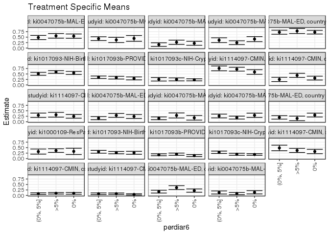

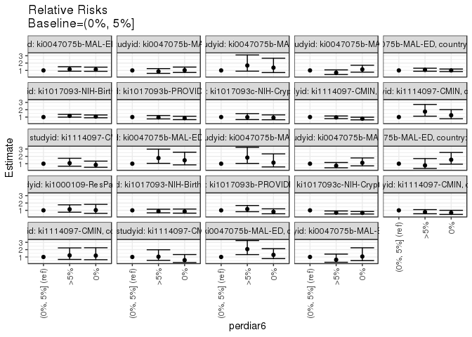

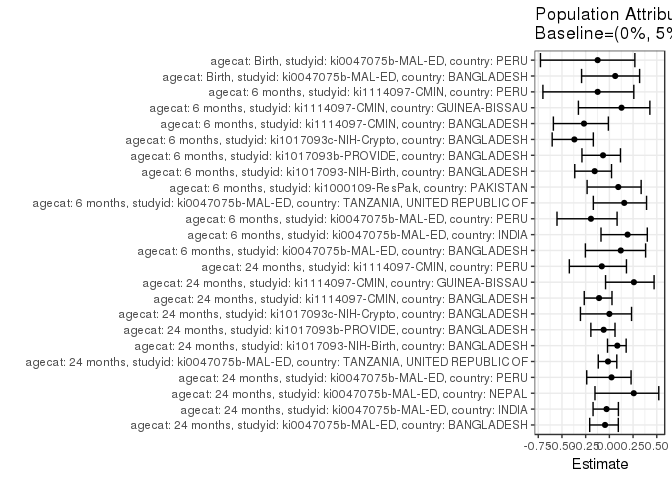

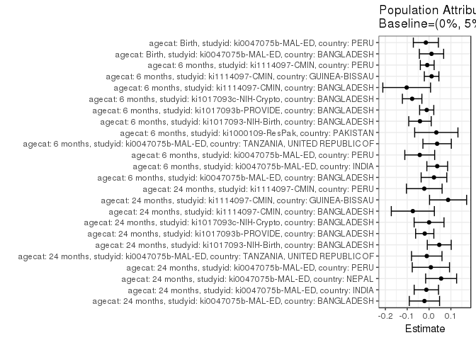

## Results Table

### Parameter: TSM

| agecat | studyid | country | intervention_level | baseline_level | estimate | ci_lower | ci_upper |
| --- | --- | --- | --- | --- | --- | --- | --- |
| Birth | ki0047075b-MAL-ED | BANGLADESH | (0%, 5%] | NA | 0.1716104 | 0.1067393 | 0.2364816 |
| Birth | ki0047075b-MAL-ED | BANGLADESH | 0% | NA | 0.2209073 | 0.1462027 | 0.2956120 |
| Birth | ki0047075b-MAL-ED | BANGLADESH | >5% | NA | 0.3553956 | 0.2672054 | 0.4435857 |
| Birth | ki0047075b-MAL-ED | PERU | (0%, 5%] | NA | 0.1331105 | 0.0623911 | 0.2038299 |
| Birth | ki0047075b-MAL-ED | PERU | 0% | NA | 0.1418574 | 0.0668003 | 0.2169145 |
| Birth | ki0047075b-MAL-ED | PERU | >5% | NA | 0.0827277 | 0.0325095 | 0.1329458 |
| 6 months | ki0047075b-MAL-ED | BANGLADESH | (0%, 5%] | NA | 0.1642489 | 0.0939313 | 0.2345666 |
| 6 months | ki0047075b-MAL-ED | BANGLADESH | 0% | NA | 0.2410935 | 0.1519311 | 0.3302559 |
| 6 months | ki0047075b-MAL-ED | BANGLADESH | >5% | NA | 0.2904027 | 0.2004719 | 0.3803334 |
| 6 months | ki0047075b-MAL-ED | INDIA | (0%, 5%] | NA | 0.1574803 | 0.0939953 | 0.2209654 |
| 6 months | ki0047075b-MAL-ED | INDIA | 0% | NA | 0.1800000 | 0.0732843 | 0.2867157 |
| 6 months | ki0047075b-MAL-ED | INDIA | >5% | NA | 0.2881356 | 0.1723269 | 0.4039443 |
| 6 months | ki0047075b-MAL-ED | PERU | (0%, 5%] | NA | 0.2624488 | 0.1773242 | 0.3475734 |
| 6 months | ki0047075b-MAL-ED | PERU | 0% | NA | 0.2943189 | 0.1966030 | 0.3920348 |
| 6 months | ki0047075b-MAL-ED | PERU | >5% | NA | 0.1888236 | 0.1211291 | 0.2565181 |
| 6 months | ki0047075b-MAL-ED | TANZANIA, UNITED REPUBLIC OF | (0%, 5%] | NA | 0.1979167 | 0.1180539 | 0.2777794 |
| 6 months | ki0047075b-MAL-ED | TANZANIA, UNITED REPUBLIC OF | 0% | NA | 0.3047619 | 0.2165390 | 0.3929848 |
| 6 months | ki0047075b-MAL-ED | TANZANIA, UNITED REPUBLIC OF | >5% | NA | 0.1521739 | 0.0481643 | 0.2561836 |
| 6 months | ki1000109-ResPak | PAKISTAN | (0%, 5%] | NA | 0.3199865 | 0.2048639 | 0.4351090 |
| 6 months | ki1000109-ResPak | PAKISTAN | 0% | NA | 0.3298571 | 0.1862542 | 0.4734599 |
| 6 months | ki1000109-ResPak | PAKISTAN | >5% | NA | 0.3657288 | 0.2827313 | 0.4487263 |
| 6 months | ki1017093-NIH-Birth | BANGLADESH | (0%, 5%] | NA | 0.3097189 | 0.2458296 | 0.3736082 |
| 6 months | ki1017093-NIH-Birth | BANGLADESH | 0% | NA | 0.2631186 | 0.1956853 | 0.3305519 |
| 6 months | ki1017093-NIH-Birth | BANGLADESH | >5% | NA | 0.2692316 | 0.2153559 | 0.3231074 |
| 6 months | ki1017093b-PROVIDE | BANGLADESH | (0%, 5%] | NA | 0.1719939 | 0.1287547 | 0.2152331 |
| 6 months | ki1017093b-PROVIDE | BANGLADESH | 0% | NA | 0.1373960 | 0.0916082 | 0.1831838 |
| 6 months | ki1017093b-PROVIDE | BANGLADESH | >5% | NA | 0.2005000 | 0.1494013 | 0.2515987 |
| 6 months | ki1017093c-NIH-Crypto | BANGLADESH | (0%, 5%] | NA | 0.2872132 | 0.2321560 | 0.3422704 |
| 6 months | ki1017093c-NIH-Crypto | BANGLADESH | 0% | NA | 0.1860634 | 0.1491157 | 0.2230111 |
| 6 months | ki1017093c-NIH-Crypto | BANGLADESH | >5% | NA | 0.1963095 | 0.1500809 | 0.2425380 |
| 6 months | ki1114097-CMIN | BANGLADESH | (0%, 5%] | NA | 0.4851751 | 0.3586052 | 0.6117450 |
| 6 months | ki1114097-CMIN | BANGLADESH | 0% | NA | 0.3236407 | 0.2215893 | 0.4256921 |
| 6 months | ki1114097-CMIN | BANGLADESH | >5% | NA | 0.3714059 | 0.2778477 | 0.4649640 |
| 6 months | ki1114097-CMIN | GUINEA-BISSAU | (0%, 5%] | NA | 0.0791192 | 0.0407775 | 0.1174608 |
| 6 months | ki1114097-CMIN | GUINEA-BISSAU | 0% | NA | 0.0940731 | 0.0546962 | 0.1334500 |
| 6 months | ki1114097-CMIN | GUINEA-BISSAU | >5% | NA | 0.0963631 | 0.0611392 | 0.1315869 |
| 6 months | ki1114097-CMIN | PERU | (0%, 5%] | NA | 0.0760870 | 0.0377470 | 0.1144270 |
| 6 months | ki1114097-CMIN | PERU | 0% | NA | 0.0434783 | 0.0139889 | 0.0729676 |
| 6 months | ki1114097-CMIN | PERU | >5% | NA | 0.0786517 | 0.0463369 | 0.1109664 |
| 24 months | ki0047075b-MAL-ED | BANGLADESH | (0%, 5%] | NA | 0.4834163 | 0.3890523 | 0.5777803 |
| 24 months | ki0047075b-MAL-ED | BANGLADESH | 0% | NA | 0.5449976 | 0.4464718 | 0.6435235 |
| 24 months | ki0047075b-MAL-ED | BANGLADESH | >5% | NA | 0.5585272 | 0.4531471 | 0.6639073 |
| 24 months | ki0047075b-MAL-ED | INDIA | (0%, 5%] | NA | 0.4309384 | 0.3449698 | 0.5169069 |
| 24 months | ki0047075b-MAL-ED | INDIA | 0% | NA | 0.4417180 | 0.3100821 | 0.5733540 |
| 24 months | ki0047075b-MAL-ED | INDIA | >5% | NA | 0.3729337 | 0.2537721 | 0.4920952 |
| 24 months | ki0047075b-MAL-ED | NEPAL | (0%, 5%] | NA | 0.1595903 | 0.0778868 | 0.2412938 |
| 24 months | ki0047075b-MAL-ED | NEPAL | 0% | NA | 0.2191858 | 0.1271691 | 0.3112024 |
| 24 months | ki0047075b-MAL-ED | NEPAL | >5% | NA | 0.2664957 | 0.1700543 | 0.3629372 |
| 24 months | ki0047075b-MAL-ED | PERU | (0%, 5%] | NA | 0.3598072 | 0.2524483 | 0.4671661 |
| 24 months | ki0047075b-MAL-ED | PERU | 0% | NA | 0.4099407 | 0.2959706 | 0.5239109 |
| 24 months | ki0047075b-MAL-ED | PERU | >5% | NA | 0.2460665 | 0.1602988 | 0.3318342 |
| 24 months | ki0047075b-MAL-ED | TANZANIA, UNITED REPUBLIC OF | (0%, 5%] | NA | 0.7254591 | 0.6328750 | 0.8180432 |
| 24 months | ki0047075b-MAL-ED | TANZANIA, UNITED REPUBLIC OF | 0% | NA | 0.7269737 | 0.6416681 | 0.8122793 |
| 24 months | ki0047075b-MAL-ED | TANZANIA, UNITED REPUBLIC OF | >5% | NA | 0.7788509 | 0.6645253 | 0.8931764 |
| 24 months | ki1017093-NIH-Birth | BANGLADESH | (0%, 5%] | NA | 0.5081159 | 0.4405074 | 0.5757245 |
| 24 months | ki1017093-NIH-Birth | BANGLADESH | 0% | NA | 0.5468716 | 0.4752919 | 0.6184512 |
| 24 months | ki1017093-NIH-Birth | BANGLADESH | >5% | NA | 0.5914110 | 0.5313703 | 0.6514517 |
| 24 months | ki1017093b-PROVIDE | BANGLADESH | (0%, 5%] | NA | 0.3491115 | 0.2924937 | 0.4057294 |
| 24 months | ki1017093b-PROVIDE | BANGLADESH | 0% | NA | 0.2961478 | 0.2286064 | 0.3636893 |
| 24 months | ki1017093b-PROVIDE | BANGLADESH | >5% | NA | 0.3316492 | 0.2685362 | 0.3947623 |
| 24 months | ki1017093c-NIH-Crypto | BANGLADESH | (0%, 5%] | NA | 0.2567573 | 0.1772492 | 0.3362653 |
| 24 months | ki1017093c-NIH-Crypto | BANGLADESH | 0% | NA | 0.2326046 | 0.1849487 | 0.2802604 |
| 24 months | ki1017093c-NIH-Crypto | BANGLADESH | >5% | NA | 0.2520075 | 0.1837163 | 0.3202986 |
| 24 months | ki1114097-CMIN | BANGLADESH | (0%, 5%] | NA | 0.7561282 | 0.6462213 | 0.8660350 |
| 24 months | ki1114097-CMIN | BANGLADESH | 0% | NA | 0.5895281 | 0.4846031 | 0.6944532 |
| 24 months | ki1114097-CMIN | BANGLADESH | >5% | NA | 0.7180773 | 0.6291056 | 0.8070490 |
| 24 months | ki1114097-CMIN | GUINEA-BISSAU | (0%, 5%] | NA | 0.2497485 | 0.1532248 | 0.3462721 |
| 24 months | ki1114097-CMIN | GUINEA-BISSAU | 0% | NA | 0.3111721 | 0.2230036 | 0.3993406 |
| 24 months | ki1114097-CMIN | GUINEA-BISSAU | >5% | NA | 0.4357938 | 0.3400884 | 0.5314992 |
| 24 months | ki1114097-CMIN | PERU | (0%, 5%] | NA | 0.2965093 | 0.1966172 | 0.3964014 |
| 24 months | ki1114097-CMIN | PERU | 0% | NA | 0.2475574 | 0.1624139 | 0.3327008 |
| 24 months | ki1114097-CMIN | PERU | >5% | NA | 0.3184272 | 0.2084915 | 0.4283629 |

### Parameter: E(Y)

| agecat | studyid | country | intervention_level | baseline_level | estimate | ci_lower | ci_upper |
| --- | --- | --- | --- | --- | --- | --- | --- |
| Birth | ki0047075b-MAL-ED | BANGLADESH | NA | NA | 0.1828794 | 0.1355257 | 0.2302330 |
| Birth | ki0047075b-MAL-ED | PERU | NA | NA | 0.1184669 | 0.0810142 | 0.1559196 |
| 6 months | ki0047075b-MAL-ED | BANGLADESH | NA | NA | 0.1867220 | 0.1374205 | 0.2360234 |
| 6 months | ki0047075b-MAL-ED | INDIA | NA | NA | 0.1949153 | 0.1442678 | 0.2455627 |
| 6 months | ki0047075b-MAL-ED | PERU | NA | NA | 0.2197802 | 0.1705687 | 0.2689917 |
| 6 months | ki0047075b-MAL-ED | TANZANIA, UNITED REPUBLIC OF | NA | NA | 0.2348178 | 0.1818480 | 0.2877876 |
| 6 months | ki1000109-ResPak | PAKISTAN | NA | NA | 0.3531915 | 0.2919518 | 0.4144312 |
| 6 months | ki1017093-NIH-Birth | BANGLADESH | NA | NA | 0.2681564 | 0.2306532 | 0.3056597 |
| 6 months | ki1017093b-PROVIDE | BANGLADESH | NA | NA | 0.1612350 | 0.1313580 | 0.1911120 |
| 6 months | ki1017093c-NIH-Crypto | BANGLADESH | NA | NA | 0.2097902 | 0.1799252 | 0.2396552 |
| 6 months | ki1114097-CMIN | BANGLADESH | NA | NA | 0.3827160 | 0.3214780 | 0.4439541 |
| 6 months | ki1114097-CMIN | GUINEA-BISSAU | NA | NA | 0.0907738 | 0.0690366 | 0.1125110 |
| 6 months | ki1114097-CMIN | PERU | NA | NA | 0.0677165 | 0.0481585 | 0.0872746 |
| 24 months | ki0047075b-MAL-ED | BANGLADESH | NA | NA | 0.4622642 | 0.3949918 | 0.5295365 |
| 24 months | ki0047075b-MAL-ED | INDIA | NA | NA | 0.4185022 | 0.3541865 | 0.4828179 |
| 24 months | ki0047075b-MAL-ED | NEPAL | NA | NA | 0.2149123 | 0.1614774 | 0.2683472 |
| 24 months | ki0047075b-MAL-ED | PERU | NA | NA | 0.3681592 | 0.3013164 | 0.4350020 |
| 24 months | ki0047075b-MAL-ED | TANZANIA, UNITED REPUBLIC OF | NA | NA | 0.7149533 | 0.6543278 | 0.7755787 |
| 24 months | ki1017093-NIH-Birth | BANGLADESH | NA | NA | 0.5547786 | 0.5076945 | 0.6018626 |
| 24 months | ki1017093b-PROVIDE | BANGLADESH | NA | NA | 0.3292894 | 0.2909105 | 0.3676684 |
| 24 months | ki1017093c-NIH-Crypto | BANGLADESH | NA | NA | 0.2568093 | 0.2190047 | 0.2946140 |
| 24 months | ki1114097-CMIN | BANGLADESH | NA | NA | 0.6818182 | 0.6230135 | 0.7406228 |
| 24 months | ki1114097-CMIN | GUINEA-BISSAU | NA | NA | 0.3369176 | 0.2813564 | 0.3924787 |
| 24 months | ki1114097-CMIN | PERU | NA | NA | 0.2745902 | 0.2184751 | 0.3307052 |

### Parameter: RR

| agecat | studyid | country | intervention_level | baseline_level | estimate | ci_lower | ci_upper |
| --- | --- | --- | --- | --- | --- | --- | --- |
| Birth | ki0047075b-MAL-ED | BANGLADESH | (0%, 5%] | (0%, 5%] | 1.0000000 | 1.0000000 | 1.0000000 |
| Birth | ki0047075b-MAL-ED | BANGLADESH | 0% | (0%, 5%] | 1.2872604 | 0.7777269 | 2.1306186 |
| Birth | ki0047075b-MAL-ED | BANGLADESH | >5% | (0%, 5%] | 2.0709436 | 1.3227553 | 3.2423287 |
| Birth | ki0047075b-MAL-ED | PERU | (0%, 5%] | (0%, 5%] | 1.0000000 | 1.0000000 | 1.0000000 |
| Birth | ki0047075b-MAL-ED | PERU | 0% | (0%, 5%] | 1.0657113 | 0.5040843 | 2.2530765 |
| Birth | ki0047075b-MAL-ED | PERU | >5% | (0%, 5%] | 0.6214960 | 0.2775069 | 1.3918838 |
| 6 months | ki0047075b-MAL-ED | BANGLADESH | (0%, 5%] | (0%, 5%] | 1.0000000 | 1.0000000 | 1.0000000 |
| 6 months | ki0047075b-MAL-ED | BANGLADESH | 0% | (0%, 5%] | 1.4678542 | 0.8398314 | 2.5655098 |
| 6 months | ki0047075b-MAL-ED | BANGLADESH | >5% | (0%, 5%] | 1.7680643 | 1.0470651 | 2.9855366 |
| 6 months | ki0047075b-MAL-ED | INDIA | (0%, 5%] | (0%, 5%] | 1.0000000 | 1.0000000 | 1.0000000 |
| 6 months | ki0047075b-MAL-ED | INDIA | 0% | (0%, 5%] | 1.1430000 | 0.5580630 | 2.3410423 |
| 6 months | ki0047075b-MAL-ED | INDIA | >5% | (0%, 5%] | 1.8296610 | 1.0354857 | 3.2329363 |
| 6 months | ki0047075b-MAL-ED | PERU | (0%, 5%] | (0%, 5%] | 1.0000000 | 1.0000000 | 1.0000000 |
| 6 months | ki0047075b-MAL-ED | PERU | 0% | (0%, 5%] | 1.1214335 | 0.7050875 | 1.7836271 |
| 6 months | ki0047075b-MAL-ED | PERU | >5% | (0%, 5%] | 0.7194682 | 0.4451788 | 1.1627563 |
| 6 months | ki0047075b-MAL-ED | TANZANIA, UNITED REPUBLIC OF | (0%, 5%] | (0%, 5%] | 1.0000000 | 1.0000000 | 1.0000000 |
| 6 months | ki0047075b-MAL-ED | TANZANIA, UNITED REPUBLIC OF | 0% | (0%, 5%] | 1.5398496 | 0.9371337 | 2.5302014 |
| 6 months | ki0047075b-MAL-ED | TANZANIA, UNITED REPUBLIC OF | >5% | (0%, 5%] | 0.7688787 | 0.3476568 | 1.7004541 |
| 6 months | ki1000109-ResPak | PAKISTAN | (0%, 5%] | (0%, 5%] | 1.0000000 | 1.0000000 | 1.0000000 |
| 6 months | ki1000109-ResPak | PAKISTAN | 0% | (0%, 5%] | 1.0308468 | 0.5858313 | 1.8139099 |
| 6 months | ki1000109-ResPak | PAKISTAN | >5% | (0%, 5%] | 1.1429507 | 0.7468732 | 1.7490738 |
| 6 months | ki1017093-NIH-Birth | BANGLADESH | (0%, 5%] | (0%, 5%] | 1.0000000 | 1.0000000 | 1.0000000 |
| 6 months | ki1017093-NIH-Birth | BANGLADESH | 0% | (0%, 5%] | 0.8495401 | 0.6150812 | 1.1733709 |
| 6 months | ki1017093-NIH-Birth | BANGLADESH | >5% | (0%, 5%] | 0.8692773 | 0.6560527 | 1.1518023 |
| 6 months | ki1017093b-PROVIDE | BANGLADESH | (0%, 5%] | (0%, 5%] | 1.0000000 | 1.0000000 | 1.0000000 |
| 6 months | ki1017093b-PROVIDE | BANGLADESH | 0% | (0%, 5%] | 0.7988422 | 0.5291296 | 1.2060351 |
| 6 months | ki1017093b-PROVIDE | BANGLADESH | >5% | (0%, 5%] | 1.1657388 | 0.8189367 | 1.6594042 |
| 6 months | ki1017093c-NIH-Crypto | BANGLADESH | (0%, 5%] | (0%, 5%] | 1.0000000 | 1.0000000 | 1.0000000 |
| 6 months | ki1017093c-NIH-Crypto | BANGLADESH | 0% | (0%, 5%] | 0.6478232 | 0.4991673 | 0.8407499 |
| 6 months | ki1017093c-NIH-Crypto | BANGLADESH | >5% | (0%, 5%] | 0.6834973 | 0.5115115 | 0.9133098 |
| 6 months | ki1114097-CMIN | BANGLADESH | (0%, 5%] | (0%, 5%] | 1.0000000 | 1.0000000 | 1.0000000 |
| 6 months | ki1114097-CMIN | BANGLADESH | 0% | (0%, 5%] | 0.6670595 | 0.4431965 | 1.0039979 |
| 6 months | ki1114097-CMIN | BANGLADESH | >5% | (0%, 5%] | 0.7655089 | 0.5328541 | 1.0997453 |
| 6 months | ki1114097-CMIN | GUINEA-BISSAU | (0%, 5%] | (0%, 5%] | 1.0000000 | 1.0000000 | 1.0000000 |
| 6 months | ki1114097-CMIN | GUINEA-BISSAU | 0% | (0%, 5%] | 1.1890045 | 0.6267491 | 2.2556583 |
| 6 months | ki1114097-CMIN | GUINEA-BISSAU | >5% | (0%, 5%] | 1.2179481 | 0.6637764 | 2.2347848 |
| 6 months | ki1114097-CMIN | PERU | (0%, 5%] | (0%, 5%] | 1.0000000 | 1.0000000 | 1.0000000 |
| 6 months | ki1114097-CMIN | PERU | 0% | (0%, 5%] | 0.5714286 | 0.2454735 | 1.3302074 |
| 6 months | ki1114097-CMIN | PERU | >5% | (0%, 5%] | 1.0337079 | 0.5395527 | 1.9804405 |
| 24 months | ki0047075b-MAL-ED | BANGLADESH | (0%, 5%] | (0%, 5%] | 1.0000000 | 1.0000000 | 1.0000000 |
| 24 months | ki0047075b-MAL-ED | BANGLADESH | 0% | (0%, 5%] | 1.1273878 | 0.8793383 | 1.4454087 |
| 24 months | ki0047075b-MAL-ED | BANGLADESH | >5% | (0%, 5%] | 1.1553752 | 0.8899033 | 1.5000416 |
| 24 months | ki0047075b-MAL-ED | INDIA | (0%, 5%] | (0%, 5%] | 1.0000000 | 1.0000000 | 1.0000000 |
| 24 months | ki0047075b-MAL-ED | INDIA | 0% | (0%, 5%] | 1.0250143 | 0.7216524 | 1.4559009 |
| 24 months | ki0047075b-MAL-ED | INDIA | >5% | (0%, 5%] | 0.8653991 | 0.5987594 | 1.2507789 |
| 24 months | ki0047075b-MAL-ED | NEPAL | (0%, 5%] | (0%, 5%] | 1.0000000 | 1.0000000 | 1.0000000 |
| 24 months | ki0047075b-MAL-ED | NEPAL | 0% | (0%, 5%] | 1.3734278 | 0.7090642 | 2.6602724 |
| 24 months | ki0047075b-MAL-ED | NEPAL | >5% | (0%, 5%] | 1.6698743 | 0.8955982 | 3.1135393 |
| 24 months | ki0047075b-MAL-ED | PERU | (0%, 5%] | (0%, 5%] | 1.0000000 | 1.0000000 | 1.0000000 |
| 24 months | ki0047075b-MAL-ED | PERU | 0% | (0%, 5%] | 1.1393343 | 0.7623985 | 1.7026303 |
| 24 months | ki0047075b-MAL-ED | PERU | >5% | (0%, 5%] | 0.6838843 | 0.4360296 | 1.0726283 |
| 24 months | ki0047075b-MAL-ED | TANZANIA, UNITED REPUBLIC OF | (0%, 5%] | (0%, 5%] | 1.0000000 | 1.0000000 | 1.0000000 |
| 24 months | ki0047075b-MAL-ED | TANZANIA, UNITED REPUBLIC OF | 0% | (0%, 5%] | 1.0020877 | 0.8453120 | 1.1879399 |
| 24 months | ki0047075b-MAL-ED | TANZANIA, UNITED REPUBLIC OF | >5% | (0%, 5%] | 1.0735972 | 0.8881133 | 1.2978197 |
| 24 months | ki1017093-NIH-Birth | BANGLADESH | (0%, 5%] | (0%, 5%] | 1.0000000 | 1.0000000 | 1.0000000 |
| 24 months | ki1017093-NIH-Birth | BANGLADESH | 0% | (0%, 5%] | 1.0762732 | 0.9004547 | 1.2864212 |
| 24 months | ki1017093-NIH-Birth | BANGLADESH | >5% | (0%, 5%] | 1.1639293 | 0.9909878 | 1.3670515 |
| 24 months | ki1017093b-PROVIDE | BANGLADESH | (0%, 5%] | (0%, 5%] | 1.0000000 | 1.0000000 | 1.0000000 |
| 24 months | ki1017093b-PROVIDE | BANGLADESH | 0% | (0%, 5%] | 0.8482901 | 0.6481057 | 1.1103066 |
| 24 months | ki1017093b-PROVIDE | BANGLADESH | >5% | (0%, 5%] | 0.9499808 | 0.7470535 | 1.2080306 |
| 24 months | ki1017093c-NIH-Crypto | BANGLADESH | (0%, 5%] | (0%, 5%] | 1.0000000 | 1.0000000 | 1.0000000 |
| 24 months | ki1017093c-NIH-Crypto | BANGLADESH | 0% | (0%, 5%] | 0.9059318 | 0.6311876 | 1.3002671 |
| 24 months | ki1017093c-NIH-Crypto | BANGLADESH | >5% | (0%, 5%] | 0.9815008 | 0.6557125 | 1.4691559 |
| 24 months | ki1114097-CMIN | BANGLADESH | (0%, 5%] | (0%, 5%] | 1.0000000 | 1.0000000 | 1.0000000 |
| 24 months | ki1114097-CMIN | BANGLADESH | 0% | (0%, 5%] | 0.7796669 | 0.6196510 | 0.9810047 |
| 24 months | ki1114097-CMIN | BANGLADESH | >5% | (0%, 5%] | 0.9496766 | 0.7846066 | 1.1494751 |
| 24 months | ki1114097-CMIN | GUINEA-BISSAU | (0%, 5%] | (0%, 5%] | 1.0000000 | 1.0000000 | 1.0000000 |
| 24 months | ki1114097-CMIN | GUINEA-BISSAU | 0% | (0%, 5%] | 1.2459418 | 0.7727074 | 2.0090024 |
| 24 months | ki1114097-CMIN | GUINEA-BISSAU | >5% | (0%, 5%] | 1.7449306 | 1.1188711 | 2.7212991 |
| 24 months | ki1114097-CMIN | PERU | (0%, 5%] | (0%, 5%] | 1.0000000 | 1.0000000 | 1.0000000 |
| 24 months | ki1114097-CMIN | PERU | 0% | (0%, 5%] | 0.8349059 | 0.5156358 | 1.3518609 |
| 24 months | ki1114097-CMIN | PERU | >5% | (0%, 5%] | 1.0739197 | 0.6627743 | 1.7401153 |

### Parameter: PAR

| agecat | studyid | country | intervention_level | baseline_level | estimate | ci_lower | ci_upper |
| --- | --- | --- | --- | --- | --- | --- | --- |
| Birth | ki0047075b-MAL-ED | BANGLADESH | (0%, 5%] | NA | 0.0112689 | -0.0443057 | 0.0668436 |
| Birth | ki0047075b-MAL-ED | PERU | (0%, 5%] | NA | -0.0146436 | -0.0720036 | 0.0427163 |
| 6 months | ki0047075b-MAL-ED | BANGLADESH | (0%, 5%] | NA | 0.0224730 | -0.0362795 | 0.0812256 |
| 6 months | ki0047075b-MAL-ED | INDIA | (0%, 5%] | NA | 0.0374349 | -0.0100810 | 0.0849509 |
| 6 months | ki0047075b-MAL-ED | PERU | (0%, 5%] | NA | -0.0426686 | -0.1110673 | 0.0257301 |
| 6 months | ki0047075b-MAL-ED | TANZANIA, UNITED REPUBLIC OF | (0%, 5%] | NA | 0.0369011 | -0.0281067 | 0.1019090 |
| 6 months | ki1000109-ResPak | PAKISTAN | (0%, 5%] | NA | 0.0332050 | -0.0658575 | 0.1322675 |
| 6 months | ki1017093-NIH-Birth | BANGLADESH | (0%, 5%] | NA | -0.0415625 | -0.0930315 | 0.0099065 |
| 6 months | ki1017093b-PROVIDE | BANGLADESH | (0%, 5%] | NA | -0.0107589 | -0.0431978 | 0.0216800 |
| 6 months | ki1017093c-NIH-Crypto | BANGLADESH | (0%, 5%] | NA | -0.0774230 | -0.1220487 | -0.0327974 |
| 6 months | ki1114097-CMIN | BANGLADESH | (0%, 5%] | NA | -0.1024591 | -0.2117444 | 0.0068262 |
| 6 months | ki1114097-CMIN | GUINEA-BISSAU | (0%, 5%] | NA | 0.0116546 | -0.0216713 | 0.0449806 |
| 6 months | ki1114097-CMIN | PERU | (0%, 5%] | NA | -0.0083704 | -0.0400026 | 0.0232617 |
| 24 months | ki0047075b-MAL-ED | BANGLADESH | (0%, 5%] | NA | -0.0211522 | -0.0904484 | 0.0481441 |
| 24 months | ki0047075b-MAL-ED | INDIA | (0%, 5%] | NA | -0.0124362 | -0.0681836 | 0.0433113 |
| 24 months | ki0047075b-MAL-ED | NEPAL | (0%, 5%] | NA | 0.0553220 | -0.0155881 | 0.1262321 |
| 24 months | ki0047075b-MAL-ED | PERU | (0%, 5%] | NA | 0.0083520 | -0.0769544 | 0.0936583 |
| 24 months | ki0047075b-MAL-ED | TANZANIA, UNITED REPUBLIC OF | (0%, 5%] | NA | -0.0105058 | -0.0802610 | 0.0592493 |
| 24 months | ki1017093-NIH-Birth | BANGLADESH | (0%, 5%] | NA | 0.0466626 | -0.0081334 | 0.1014587 |
| 24 months | ki1017093b-PROVIDE | BANGLADESH | (0%, 5%] | NA | -0.0198221 | -0.0615754 | 0.0219312 |
| 24 months | ki1017093c-NIH-Crypto | BANGLADESH | (0%, 5%] | NA | 0.0000521 | -0.0683656 | 0.0684698 |
| 24 months | ki1114097-CMIN | BANGLADESH | (0%, 5%] | NA | -0.0743100 | -0.1729374 | 0.0243174 |
| 24 months | ki1114097-CMIN | GUINEA-BISSAU | (0%, 5%] | NA | 0.0871691 | 0.0022636 | 0.1720746 |
| 24 months | ki1114097-CMIN | PERU | (0%, 5%] | NA | -0.0219191 | -0.1035664 | 0.0597281 |

### Parameter: PAF

| agecat | studyid | country | intervention_level | baseline_level | estimate | ci_lower | ci_upper |
| --- | --- | --- | --- | --- | --- | --- | --- |
| Birth | ki0047075b-MAL-ED | BANGLADESH | (0%, 5%] | NA | 0.0616195 | -0.2931046 | 0.3190358 |
| Birth | ki0047075b-MAL-ED | PERU | (0%, 5%] | NA | -0.1236095 | -0.7269764 | 0.2689546 |
| 6 months | ki0047075b-MAL-ED | BANGLADESH | (0%, 5%] | NA | 0.1203556 | -0.2528479 | 0.3823878 |
| 6 months | ki0047075b-MAL-ED | INDIA | (0%, 5%] | NA | 0.1920575 | -0.0882688 | 0.4001748 |
| 6 months | ki0047075b-MAL-ED | PERU | (0%, 5%] | NA | -0.1941420 | -0.5523845 | 0.0814291 |
| 6 months | ki0047075b-MAL-ED | TANZANIA, UNITED REPUBLIC OF | (0%, 5%] | NA | 0.1571480 | -0.1690534 | 0.3923293 |
| 6 months | ki1000109-ResPak | PAKISTAN | (0%, 5%] | NA | 0.0940141 | -0.2348064 | 0.3352720 |
| 6 months | ki1017093-NIH-Birth | BANGLADESH | (0%, 5%] | NA | -0.1549934 | -0.3650674 | 0.0227517 |
| 6 months | ki1017093b-PROVIDE | BANGLADESH | (0%, 5%] | NA | -0.0667281 | -0.2891795 | 0.1173387 |
| 6 months | ki1017093c-NIH-Crypto | BANGLADESH | (0%, 5%] | NA | -0.3690498 | -0.6033244 | -0.1690069 |
| 6 months | ki1114097-CMIN | BANGLADESH | (0%, 5%] | NA | -0.2677156 | -0.5906924 | -0.0103166 |
| 6 months | ki1114097-CMIN | GUINEA-BISSAU | (0%, 5%] | NA | 0.1283919 | -0.3264673 | 0.4272752 |
| 6 months | ki1114097-CMIN | PERU | (0%, 5%] | NA | -0.1236097 | -0.7010842 | 0.2578270 |
| 24 months | ki0047075b-MAL-ED | BANGLADESH | (0%, 5%] | NA | -0.0457577 | -0.2074591 | 0.0942889 |
| 24 months | ki0047075b-MAL-ED | INDIA | (0%, 5%] | NA | -0.0297159 | -0.1719060 | 0.0952220 |
| 24 months | ki0047075b-MAL-ED | NEPAL | (0%, 5%] | NA | 0.2574165 | -0.1517615 | 0.5212288 |
| 24 months | ki0047075b-MAL-ED | PERU | (0%, 5%] | NA | 0.0226858 | -0.2387446 | 0.2289427 |
| 24 months | ki0047075b-MAL-ED | TANZANIA, UNITED REPUBLIC OF | (0%, 5%] | NA | -0.0146944 | -0.1171090 | 0.0783309 |
| 24 months | ki1017093-NIH-Birth | BANGLADESH | (0%, 5%] | NA | 0.0841104 | -0.0194690 | 0.1771660 |
| 24 months | ki1017093b-PROVIDE | BANGLADESH | (0%, 5%] | NA | -0.0601966 | -0.1951339 | 0.0595056 |
| 24 months | ki1017093c-NIH-Crypto | BANGLADESH | (0%, 5%] | NA | 0.0002028 | -0.3050834 | 0.2340762 |
| 24 months | ki1114097-CMIN | BANGLADESH | (0%, 5%] | NA | -0.1089880 | -0.2648635 | 0.0276782 |
| 24 months | ki1114097-CMIN | GUINEA-BISSAU | (0%, 5%] | NA | 0.2587253 | -0.0402668 | 0.4717814 |
| 24 months | ki1114097-CMIN | PERU | (0%, 5%] | NA | -0.0798249 | -0.4223430 | 0.1802105 |